# Practical work on LDA

The goal is to apply LDA on the Wine dataset, available in the `pgmm` package.

# Library and dataset imports

```r
# we'll use this package to load the data
#install.packages("pgmm")
#install.packages('mvtnorm')
library(pgmm); library(mvtnorm)
```

Once the package are loaded, we can load the data in the environment.

```r
data(wine)
head(wine)
```

|  | Type | Alcohol | Sugar-free Extract | Fixed Acidity | Tartaric Acid | Malic Acid | Uronic Acids | pH | Ash | Alcalinity of Ash | Potassium | Calcium | Magnesium | Phosphate | Chloride | Total Phenols | Flavanoids | Non-flavanoid Phenols | Proanthocyanins | Color Intensity | Hue | OD280/OD315 of Diluted Wines | OD280/OD315 of Flavanoids | Glycerol | 2-3-Butanediol | Total Nitrogen | Proline | Methanol |
| --- | --- | --- | --- | --- | --- | --- | --- | --- | --- | --- | --- | --- | --- | --- | --- | --- | --- | --- | --- | --- | --- | --- | --- | --- | --- | --- | --- | --- |
| 1 | 1 | 14.23 | 24.82 | 73.1 | 1.21 | 1.71 | 0.72 | 3.38 | 2.43 | 15.6 | 950 | 62 | 127 | 320 | 82 | 2.80 | 3.06 | 0.28 | 2.29 | 5.64 | 1.04 | 3.92 | 4.77 | 9.29 | 757 | 153 | 1065 | 113 |
| 2 | 1 | 13.20 | 26.30 | 72.8 | 1.84 | 1.78 | 0.71 | 3.30 | 2.14 | 11.2 | 765 | 75 | 100 | 395 | 90 | 2.65 | 2.76 | 0.26 | 1.28 | 4.38 | 1.05 | 3.40 | 3.80 | 8.93 | 881 | 194 | 1050 | 94 |
| 3 | 1 | 13.16 | 26.30 | 68.5 | 1.94 | 2.36 | 0.84 | 3.48 | 2.67 | 18.6 | 936 | 70 | 101 | 497 | 67 | 2.80 | 3.24 | 0.30 | 2.81 | 5.68 | 1.03 | 3.17 | 3.46 | 11.74 | 900 | 206 | 1185 | 125 |
| 4 | 1 | 14.37 | 25.85 | 74.9 | 1.59 | 1.95 | 0.72 | 3.43 | 2.50 | 16.8 | 985 | 47 | 113 | 580 | 49 | 3.85 | 3.49 | 0.24 | 2.18 | 7.80 | 0.86 | 3.45 | 3.54 | 10.13 | 1119 | 292 | 1480 | 80 |
| 5 | 1 | 13.24 | 26.05 | 83.5 | 1.30 | 2.59 | 1.10 | 3.42 | 2.87 | 21.0 | 1088 | 70 | 118 | 408 | 65 | 2.80 | 2.69 | 0.39 | 1.82 | 4.32 | 1.04 | 2.93 | 3.22 | 10.27 | 799 | 215 | 735 | 73 |
| 6 | 1 | 14.20 | 28.40 | 79.9 | 2.14 | 1.76 | 0.96 | 3.39 | 2.45 | 15.2 | 868 | 71 | 112 | 418 | 58 | 3.27 | 3.39 | 0.34 | 1.97 | 6.75 | 1.05 | 2.85 | 3.16 | 10.85 | 865 | 364 | 1450 | 68 |

```r
# ?wine
X = as.matrix(wine[,c(2,4)])
dim(X)
```

```
[1] 178   2
```

```r
colnames(X)
```

```
[1] "Alcohol"       "Fixed Acidity"
```

```r
y = as.numeric(wine$Type!=1)+1
```

It is of course possible to look at the data.

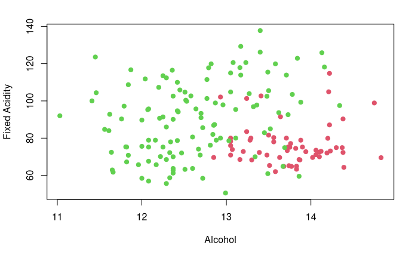

```r
plot(X, col = y+1, pch=19)
```

# Classification with LDA

The first step is to learn the LDA model from the data (i.e. estimate from the data the model parameters). Once the model is learned we will be able to classify new data to one of the two classes.

LDA assumes the following model:

$$p(X|Z = 1; \mu, \sigma) = \mathcal{N}((x; \mu_k, \Sigma)$$

> The covariance matrix is the full one. Only $\mu$ depends on the class

and
$$P(Z=k) = \pi_k$$

The ML estimation leads to the following updates:

$$\hat{\pi}_k = \sum_{i=1}^n \mathbb{1}(z_i=k)/n$$
$$\hat{\mu_k} = \sum_{i=1} \mathbb{1}(z_i = k) x_i / n_k$$
$$\hat{\Sigma} = \frac{1}{n}\sum_{k=1}^K n_k S_k$$
where:
$$S_k = \frac{1}{n_k}\sum_{i=1}^n \mathbb{1}(z_i = k) (x_i - \hat{\mu_k})^t (x_i -\hat{\mu_k})$$

# Programming an LDA model

```r
lda.learn <- function(X, z) {
  n = nrow(X); p=ncol(X)
  K = max(z)
  prop = rep(NA, K)
  mu = matrix(NA, K, p)
  Sigma = matrix(0, p, p)
  for (k in 1:K){
    n_k     = sum(z==k)
    prop[k] = n_k/n
    mu[k,]  = colSums(X[z==k,])/n_k
    Sigma   = Sigma + n_k / n * cov(X[z == k,])
  }
  return(list(prop = prop, mu = mu, Sigma = Sigma))
}

ldaDF.learn <- function(X_dataframe, y) {
  means <- aggregate(X_dataframe, by=list(y), FUN=mean)
  covariance <-  cov(X_dataframe)
  return(list(mu = means, Sigma = covariance))
}
```

```r
lda = lda.learn(X, y)
#lda = ldaDF.learn(wine[,c(2,4)], y)
lda
```

```
$prop
[1] 0.3314607 0.6685393

$mu
         [,1]     [,2]
[1,] 13.74475 76.72203
[2,] 12.63168 90.06639

$Sigma
                Alcohol Fixed Acidity
Alcohol       0.3846606      2.708836
Fixed Acidity 2.7088362    311.991616
```

# Classification

For the classification step, we use the Maximum A-Posteriori (MAP) rule:
$$z^* = argmax_k P(Z=k|X=x^*)$$
To compute those posterior probabilities from the data and the learned parameter, we can rely on the Bayes’ rule:
$$P(Z=k|X=x^*, \hat{\theta}) = \frac{P(Z=k|\hat{\theta})P(x^*|Z=k, \hat{\theta})}{P(x)}$$
$$P(Z=k|X=x^*, \hat{\theta}) = \frac{\hat{\pi}_k.\phi(x^*|\hat{\mu}_k, \hat{\Sigma})}{P(x)}$$
Where $\phi$ is the PDF of the Gaussian distribution.

So, the prediction step of LDA resumes to the computation of the $K$ posterior probabilities $P(Z=k|X=x^*)$ with the above formulas:

```r
lda.predict <- function(xstar, params){
  K = length(params$prop)
  Prob = matrix(NA, nrow(xstar), K)
  for (k in 1:K){
    Prob[,k] = params$prop[k] * dmvnorm(xstar, params$mu[k,], params$Sigma)
  }
  Prob = t(apply(Prob, 1, FUN = function(x){x/sum(x)}))
  zstar = apply(Prob, 1, FUN = which.max)
  return(list(probabilities = Prob, classification = zstar))
}
```

```r
predictions = lda.predict(X, lda)
predictions
```

```
$probabilities
               [,1]        [,2]
  [1,] 9.730892e-01 0.026910774
  [2,] 5.261417e-01 0.473858272
  [3,] 5.694259e-01 0.430574146
  [4,] 9.808137e-01 0.019186343
  [5,] 3.698148e-01 0.630185208
  [6,] 9.523072e-01 0.047692780
  [7,] 9.915809e-01 0.008419083
  [8,] 9.516868e-01 0.048313249
  [9,] 9.972407e-01 0.002759270
 [10,] 9.347184e-01 0.065281592
 [11,] 9.604168e-01 0.039583195
 [12,] 9.618779e-01 0.038122086
 [13,] 8.593529e-01 0.140647061
```

[output cut: 171 more lines]

# Classification on the whole dataset

Let’s now come back to the full 3-class wine dataset and classify it with LDA, using the minimal setup (train/test split, at 33%) to evaluate in a correct way the performance of LDA on this problem.

```r
dataset = wine[sample(1:length(wine$Type)),]
X = dataset[, -1] #excluding the first column: label
y = dataset$Type
```

### Splitting train and test sets

```r
split = round(2/3*length(y))
X_train = X[0:split,]
X_test = X[split:length(y),]
y_train = y[0:split]
y_test = y[split:length(y)]
```

Other way:

```r
training_set = sample(nrow(X), round(2/3*length(y)))
split = round(2/3*length(y))
X_train = X[training_set,]
X_test = X[-training_set,]
y_train = y[training_set]
y_test = y[-training_set]
```

```r
model = lda.learn(X_train, y_train)
model
```

```
$prop
[1] 0.3193277 0.4117647 0.2689076

$mu
         [,1]     [,2]      [,3]     [,4]     [,5]      [,6]     [,7]     [,8]     [,9]    [,10]    [,11]
[1,] 13.78658 26.80263  76.18421 1.660789 2.007895 0.7802632 3.322368 2.458684 17.03947 895.3947 66.89474
[2,] 12.26714 23.91612  79.94082 1.924082 1.863878 0.8077551 3.313469 2.208571 20.18163 850.8367 90.67347
[3,] 13.21719 24.67094 105.08750 2.731875 3.359062 1.1568750 3.250000 2.416562 21.37500 886.8125 74.46875
         [,12]    [,13]    [,14]    [,15]     [,16]     [,17]    [,18]    [,19]     [,20]    [,21]    [,22]
[1,] 106.50000 427.5000 77.21053 2.853158 2.9950000 0.2871053 1.945526 5.719737 1.0565789 3.092632 3.366053
[2,]  92.91837 316.2857 71.53061 2.208367 1.9855102 0.3626531 1.619592 3.002041 1.0507347 2.778163 3.316531
[3,]  99.00000 338.4688 41.40625 1.650625 0.8128125 0.4406250 1.224687 8.029375 0.6615625 1.679688 1.891250
         [,23]    [,24]    [,25]     [,26]    [,27]
[1,] 10.103947 767.9737 277.6316 1154.0000 111.3947
[2,]  7.957347 663.8163 236.5102  517.4898 103.5102
[3,]  8.747500 797.9375 206.0312  619.2188 120.4688

$Sigma
                                   Alcohol Sugar-free Extract Fixed Acidity Tartaric Acid    Malic Acid
Alcohol                       0.2739341522        0.069293454   -1.18269785  1.252745e-02  -0.032073938
Sugar-free Extract            0.0692934539        3.277051142    6.08622549 -2.134105e-01   0.282071175
Fixed Acidity                -1.1826978453        6.086225488  206.21678578  1.936807e+00   6.990377322
Tartaric Acid                 0.0125274509       -0.213410483    1.93680696  2.326067e-01  -0.033520025
Malic Acid                   -0.0320739383        0.282071175    6.99037732 -3.352002e-02   0.873472714
Uronic Acids                  0.0162816787        0.031843533    0.21530767 -3.237377e-03   0.042727666
pH                            0.0056980173       -0.008497112   -1.10346760 -3.136239e-02  -0.029131767
Ash                          -0.0079249086        0.194541153    0.03635029 -3.656908e-02   0.005856583
Alcalinity of Ash            -0.1014840054        0.967151597    1.49581846 -3.326035e-01   0.337396324
Potassium                    -8.5089368563       59.476052100  156.44273192 -1.129887e+01   3.328583177
Calcium                      -3.5768231338        5.794339866  132.50562364  1.244973e+00   2.931035987
Magnesium                    -0.2048349442       -0.197509243    2.34963207 -3.267095e-02  -1.546475877
Phosphate                     2.1041335789        3.895380280  -91.36462112  1.089661e+01 -17.374669994
Chloride                     -0.7944489766       12.853483734  -35.30328152 -1.508830e+00  -7.081650069
Total Phenols                 0.0157140781        0.260734800    0.74157944  3.174135e-03  -0.029652962
Flavanoids                    0.0102211029        0.335005247    0.88178553 -1.638083e-02  -0.021070658
Non-flavanoid Phenols         0.0020956852        0.001775558    0.15648646 -3.183400e-03   0.020765265
Proanthocyanins              -0.0093061615        0.243469610    1.25089830  2.722630e-02   0.018677419
Color Intensity               0.2509918786        0.100361554    1.47309987  2.343646e-01  -0.329746693
Hue                          -0.0006869842        0.007110586   -1.03061526 -5.160548e-03  -0.034206309
OD280/OD315 of Diluted Wines -0.0200065156        0.138317998    0.57012694  3.106347e-03   0.048392263
```

[output cut: 131 more lines]

```
Phosphate                       523.6432868  2632.672368   47.17870269
Chloride                       -155.6830727   439.075649  112.63994414
Total Phenols                     0.5204939     9.458181    0.74347329
Flavanoids                       -0.9921999     3.768052   -0.06705868
Non-flavanoid Phenols             0.3343541    -1.152971    0.11861458
Proanthocyanins                  -3.8789378     9.078297    0.45243628
Color Intensity                  -3.7186873    84.342274    0.88559138
Hue                               0.7887962     4.797281    0.63799071
OD280/OD315 of Diluted Wines     -1.0960320    -8.724801    0.46090556
OD280/OD315 of Flavanoids        -3.3080600   -15.263436    0.61189325
Glycerol                          4.6339328   -15.468790    8.08344013
2-3-Butanediol                  553.3421697  4531.407836 -116.00814984
Total Nitrogen                 4079.7982018  3107.717107    6.47344095
Proline                        3107.7171071 31356.758827  -61.70146012
Methanol                          6.4734409   -61.701460  571.40352191
```

### Prediction on test set

```r
predictions = lda.predict(X_test, model)
predictions
```

```
$probabilities
              [,1]         [,2]         [,3]
 [1,] 1.122926e-10 1.000000e+00 1.774007e-09
 [2,] 1.828054e-17 5.047907e-08 9.999999e-01
 [3,] 1.000000e+00 4.591655e-11 4.245529e-29
 [4,] 1.000000e+00 3.316696e-08 1.087508e-21
 [5,] 4.793333e-11 1.000000e+00 5.355665e-14
 [6,] 9.404541e-13 1.000000e+00 2.079549e-10
 [7,] 3.984723e-19 1.616582e-07 9.999998e-01
 [8,] 1.000000e+00 3.429962e-11 4.070047e-28
 [9,] 6.077737e-27 7.857338e-12 1.000000e+00
[10,] 2.230589e-07 2.061815e-05 9.999792e-01
[11,] 1.000000e+00 7.642824e-13 1.868107e-23
[12,] 3.069587e-24 9.269889e-15 1.000000e+00
[13,] 5.606073e-13 6.596840e-03 9.934032e-01
```

[output cut: 50 more lines]

### Measuring Accuracy

```r
nb_match = sum(predictions$classification != y_test)

cat("\n: Classification table:\n")
```

```
: Classification table:
```

```r
table(y_test, predictions$classification)
```

```
y_test  1  2  3
     1 21  0  0
     2  0 21  1
     3  0  0 16
```

```r
cat("\nError Rate:", nb_match/length(y_test))
```

```
Error Rate: 0.01694915
```